# hw4 Yirun Wang (aaron.wang@wisc.edu)

**Introduction**  
In order to find the closest measure of the cB58 in an undiscovered, gravitationally lensed, high-redshift Lyman-break galaxy, I built the base model firstly. For the base model, I tried to use Manhattan distance to measure the distance between each point. The reason I use Manhattan distance is that I believe calculating the distance between each point is the most stright-forward method to find the closest spectrum. The first step is to standardize the flux. Since there is no built-in function in R to calculate the Manhattan distance, I wrote the function by myself. However, it did not work since it did not put the noisy version of cB58 in the top three distance. Then, I used another distance which is Minkowski distance. As for this distance, I chose p = 3 and p = 4 but none of them worked. I believe one of the reasons for the failure is the value of k. Keeping all the codes the same, I finally turned to Euclidean distance. This distance finally put the noisy version in the third place. By plotting the graph, there is enough evidence that this method is effective.

Then, using the base model and CHTC, I am able to do the computation in a large scale. Firstly, I wrote sh file which unpacks R, unpacks the FITSio package, tells bash where R is, tells R where itself and its libraries are, unpacks the current .tgz file and runs hw4.R on that directory. Then, I wrote a sub file to transfer 3586.tgz to a compute node, extract it to a directory containing 1000 .fits files, run hw4.R on the 3586 directory, and return the csv file. However, I met several problems with my base model. It does not consider spectra shorter than cB58 and some NA values in the computation of distances. Therefore, I wrote two if statement to check for the length of the spectra and NA values and use next in R to ignore them. Finally, I successfully get the 100 spectras that fits cB58 the most.

```r
rm(list=ls())
require("FITSio")
cB58 = readFrameFromFITS("cB58_Lyman_break.fit")
n=dim(cB58)[1]
spec = read.csv(file = 'hw4best100.csv', header = FALSE)
new_cB58 = (cB58$FLUX-mean(cB58$FLUX))/sd(cB58$FLUX)
```

## Fitting Plots

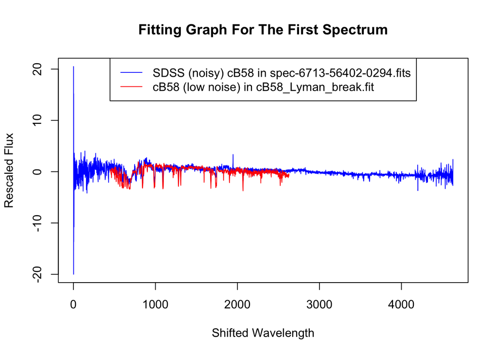

```r
spec1 = readFrameFromFITS(spec[1, 2])
data1 = spec1$flux
point1 = spec[1, 3]
new_spec1 = (data1-mean(data1))/sd(data1)
plot(x=1:dim(spec1)[1], y=new_spec1, type='n', main = 'Fitting Graph For The First Spectrum',xlab = 'Shifted Wavelength',ylab = 'Rescaled Flux'); lines(x=1:dim(spec1)[1],y= new_spec1, col = 'blue'); lines(x=point1:(point1+n-1),y=new_cB58,col='red')
legend("top", legend=c(paste(sep = "","SDSS (noisy) cB58 in " , spec[1, 2]), "cB58 (low noise) in cB58_Lyman_break.fit"), col=c("blue", "red"), lty=c(1, 1))
```

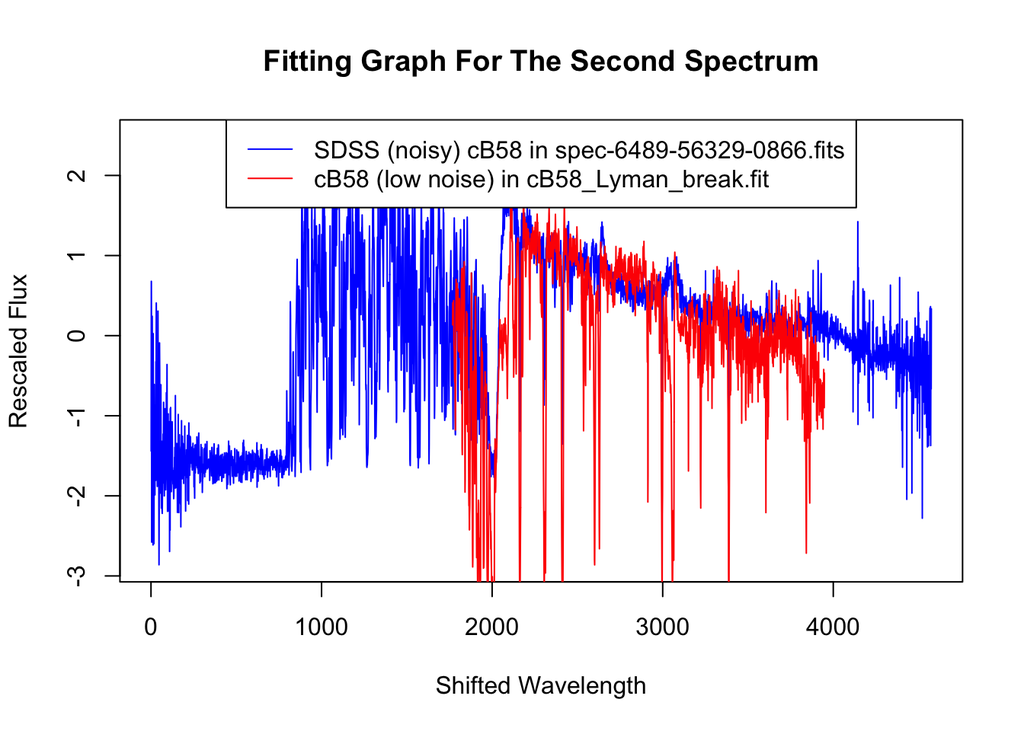

```r
spec2 = readFrameFromFITS(spec[2, 2])
data2 = spec2$flux
point2 = spec[2, 3]
new_spec2 = (data2-mean(data2))/sd(data2)
plot(x=1:dim(spec2)[1], y=new_spec2, type='n', main = 'Fitting Graph For The Second Spectrum',xlab = 'Shifted Wavelength',ylab = 'Rescaled Flux'); lines(x=1:dim(spec2)[1],y= new_spec2, col = 'blue'); lines(x=point2:(point2+n-1),y=new_cB58,col='red')
legend("top", legend=c(paste(sep = "","SDSS (noisy) cB58 in " ,spec[2, 2]) , "cB58 (low noise) in cB58_Lyman_break.fit"), col=c("blue", "red"), lty=c(1, 1))
```

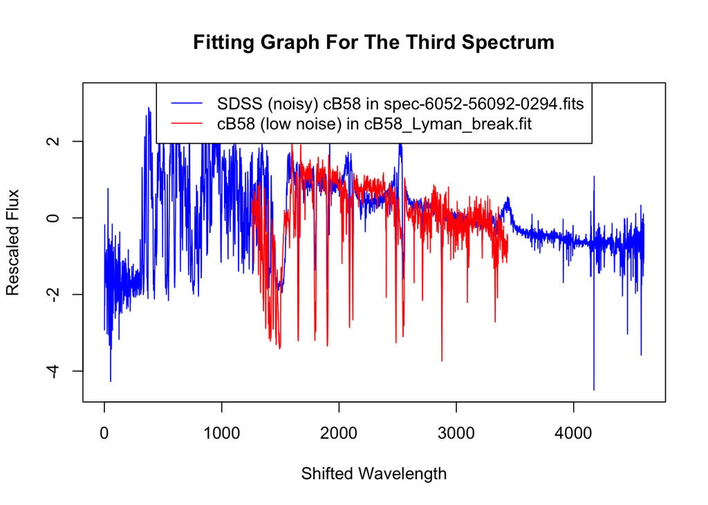

```r
spec3 = readFrameFromFITS(spec[3, 2])
data3 = spec3$flux
point3 = spec[3, 3]
new_spec3 = (data3-mean(data3))/sd(data3)
plot(x=1:dim(spec3)[1], y=new_spec3, type='n', main = 'Fitting Graph For The Third Spectrum',xlab = 'Shifted Wavelength',ylab = 'Rescaled Flux'); lines(x=1:dim(spec3)[1],y= new_spec3, col = 'blue'); lines(x=point3:(point3+n-1),y=new_cB58,col='red')
legend("top", legend=c(paste(sep = "","SDSS (noisy) cB58 in " ,spec[3, 2]) , "cB58 (low noise) in cB58_Lyman_break.fit"), col=c("blue", "red"), lty=c(1, 1))
```